# (R)Markdown and Github

Julie Lowndes

August 18, 2016

# 1 Objectives

1. learn markdown, practice
2. if time: learn Rmarkdown, create a document based on survey analysis
3. add their neighbor as a collaborator to their repo
4. practice more; make changes to their repo, and to their neighbor’s.

[figure not shown]

# 2 Intro to Markdown

Let’s learn markdown by editing the `README.md` on github.com for convenience. A README.md file can be added to every folder in a repository, and they are automatically displayed when the repository is opened on github.com

The `README.md` is in **markdown**, simple syntax for conversion to HTML. `.md` is a kind of text file, so you only need a text editor to read it. If you were editing this on your computer, you could do this right in RStudio, which has a built-in text editor. (You could also do it in another text editor program, but RStudio is convenient). Copy-paste the following into your `README.md`:

```
# my-project

Playing with [Data Carpentry at UC Merced -  Yosemite](https://snacktavish.github.io/2017-08-17-Yosemite/).

## Introduction

This repository demonstrates **software** and _formats_:

1. **Git**
1. **Github**
1. _Markdown_
1. _Rmarkdown_

## Conclusion

![](https://octodex.github.com/images/labtocat.png)
```

Now click on the Preview button to see the markdown rendered as HTML.

Notice the syntax for:

- **numbered list** gets automatically sequenced: `1.`, `1.`
- **headers** get rendered at multiple levels: `#`, `##`
- **link**: `[](http://...)`
- **image**: `![](http://...)`
- *italics*: `_word_`
- **bold**: `**word**`

There are some good [cheatsheets](https://github.com/adam-p/markdown-here/wiki/Markdown-Here-Cheatsheet) to get you started, and here is one built into RStudio:

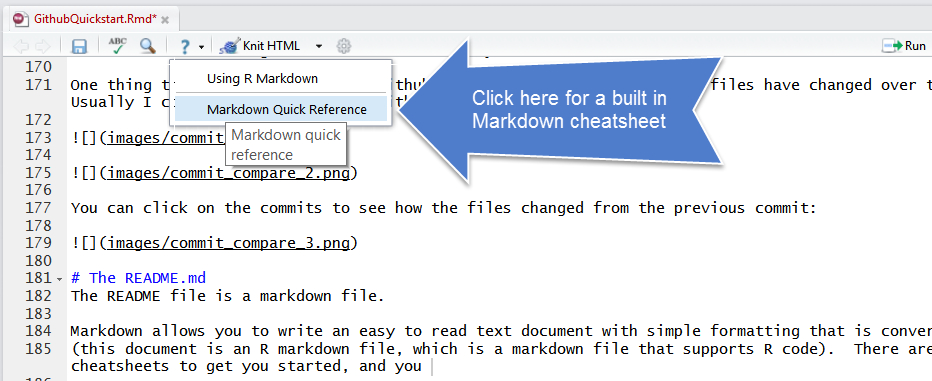

See [Mastering Markdown · GitHub Guides](https://guides.github.com/features/mastering-markdown/) and add some more personalized content to the README of your own, like a bulleted list or blockquote. For on the fly rendering, the [atom](https://atom.io/) text editor is good.

# 3 Commit this README.md

Have a look through the repo on github.com to see the updates you’ve made, and notice that it renders below the files in the repo. This is a unique trait of README.md

# 4 Rmarkdown from RStudio

Back in RStudio, let’s create a new Rmarkdown file, which allows us to weave markdown text with chunks of R code to be evaluated and output content like tables and plots.

File -> New File -> Rmarkdown… -> Document of output format HTML, OK.

[figure not shown]

You can give it a Title of “My Project”. After you click OK, most importantly File -> Save as `index` (which will get named with the filename extension `index.Rmd`).

Some initial text is already provided for you. Let’s go ahead and “Knit HTML”.

Notice how the markdown is rendered similar to as before + **R code chunks** are surrounded by 3 backticks and `{r LABEL}`. These are evaluated and return the output text in the case of `summary(cars)` and the output plot in the case of `plot(pressure)`.

Notice how the code `plot(pressure)` is not shown in the HTML output because of the R code chunk option `echo=FALSE`.

**Before we continue exploring Rmarkdown**, let’s sync this the .rmd and .html to github.com. Enter a message like “added index” and click on “Commit and Sync gh-pages”. This will update https://github.com/USER/my-project, and now you can also see your project website with a default `index.html` viewable at http://USER.github.io/my-project

## 4.1 Resources

Were you hoping for an RStudio Cheatsheet? Here it is:

- [rmarkdown-cheatsheet.pdf](http://www.rstudio.com/wp-content/uploads/2016/03/rmarkdown-cheatsheet-2.0.pdf)
- http://rmarkdown.rstudio.com
- [knitr in a knutshell - Karl Broman](http://kbroman.org/knitr_knutshell/)

# 5 Add your neighbor as a collaborator

In github.com; we’ll walk through this together. Then, practice more; make changes to their repo, and to their neighbor’s.

# 6 Wrapup

# 7 References

- ggplot2-cheatsheet-2.0.pdf
- [Interactive Plots and Maps - Environmental Informatics](http://ucsb-bren.github.io/env-info/wk06_widgets.html)
- [Graphs with ggplot2 - Cookbook for R](http://www.cookbook-r.com/Graphs/#graphs-with-ggplot2)
- [ggplot2 Essentials - STHDA](http://www.sthda.com/english/wiki/ggplot2-essentials)
- [NEON Working with Geospatial Data](http://neon-workwithdata.github.io/NEON-R-Spatio-Temporal-Data-and-Management-Intro/)